# Analyse en Composantes Principales

M2 IGAST / Mastère DESIGEO

2021-2022

# Introduction

# Dans les cours précédents …

Techniques pour quantifier la liaison entre **2** variables (quali ou quanti).

$\chi^2$ , corrélation linéaire, régression linéaire

# Motivation

La plupart des phénomènes intéressants (sociaux, spatiaux) sont **multi-factoriels**. Les données disponibles pour les décrire sont

$\rightarrow$ Partiellement **redondantes** : e.g. revenu et profession  
$\rightarrow$ Intrinsèquement **corrélées** : e.g. revenu et taille du logement  
$\rightarrow$ Parfois des **proportions** (somme à 1 ou 100%)

# Quoi et comment ?

L’Analyse **factorielle** cherche à réduire la **colinéarité** et le **nombre de dimensions** (=variables) qui décrivent une population …

… en proposant de nouvelles variables **composites décorrélées**

# Plusieurs dimensions

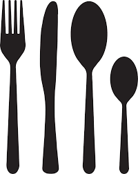

# Dimension “composite”

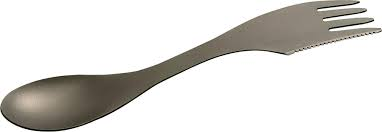

Comment **constituer** ces **nouvelles** dimensions composites ?

# L’inertie

L’inertie est l’équivalent **multi-dimensionnel** de la **variance** d’une variable.

C’est une notion centrale de l’ACP.

$I= \frac{1}{n}\sum_{i=1}^n d(x_i,g)$  
Avec :  
- $n$ la taille de la population  
- $x_i$ la valeur de la variable de l’individu $i$  
- $g$ le point moyen  
- $d(x,y)$ une distance

# L’inertie

L’inertie quantifie la **dispersion** du nuage de points

C’est la **somme** des variances des variables

Inertie faible : peu de variété dans les variables, individus semblables $\rightarrow$ faible quantité d’information

# L’inertie (1D)

en 1D , l’inertie est la **variance** :
$$I= \frac{1}{n}\sum_{i=1}^n (x_i-\bar{x})^2$$
le point moyen a pour “coordonnées” $\bar{x}$

# L’inertie (2D)

Soient $x$ et $y$ deux variables qui décrivent des individus $p_i$ de la population $P$, et $g$ le point (individu) moyen de cette population.

L’inertie de $P$ est :
$$I= \frac{1}{n}\sum_{i=1}^n (x_i-x_g)^2 + (y_i-y_g)^2$$

On reconnaît une somme de variances : $I=var(x)+var(y)$

# L’inertie (nD)

Soient $v$ variables , notées $x^{(k)}, k \in \{1,\dots,v\}$ qui décrivent les individus d’une population $P$, le point moyen de $P$ est noté $g$.

L’inertie de $P$ est :
$$I= \frac{1}{n}\sum_{k=1}^v\sum_{i=1}^n (x_i^{(k)}-x^{(k)}_g)^2$$

on reconnaît :
$$I= \sum_{k=1}^v var(x^{(k)})$$

# Espaces, vecteurs, axes, variables.

Une population statistique $P$ est décrite par plusieurs variables continues.

Ces variables définissent un **espace vectoriel** : un individu y est un **vecteur** , la valeur de ses variables sont les **coordonnées** du vecteur dans cet espace.

Chaque variable est une **dimension** de cet espace vectoriel.

Ces variables sont (potentiellement) **corrélées**.

# Explicitation de l’ACP

L’ACP consiste à trouver des **axes** indépendants (orthogonaux entre eux), qui capturent le **plus d’inertie possible** de la population $P$.

l’ACP est le calcul d’une **transformation** linéaire qui re-projette des vecteurs-individus et des vecteurs-variables dans un nouvel **espace**, constitué par les **axes**.

En général on choisit $\#axes < \#dimensions$

# Contributions des individus

# Qualité de la représentation